# Презентация по лабораторной работе №1

Дисциплина: Администрирование локальных сетей

Лобанова П.И.

Российский университет дружбы народов, Москва, Россия

07 февраля 2025

# Информация

## Докладчик

- Лобанова Полина Иннокентьевна
- Учащаяся на направлении “Фундаментальная информатика и информационные технологии”
- Студентка группы НФИбд-02-22
- polla-2004@mail.ru

# Цель работы

Установка инструмента моделирования конфигурации сети Cisco Packet Tracer, знакомство с его интерфейсом.

# Задание

1. Установить на домашнем устройстве Cisco Packet Tracer.
2. Постройте простейшую сеть в Cisco Packet Tracer, проведите простейшую настройку оборудования.

# Выполнение

Установила в своей операционной системе Cisco Packet Tracer и заблокировала для него доступ в Интернет.

[figure not shown]

*Запущенная программа*

Создала новый проект. В рабочем пространстве разместила концентратор (Hub-PT) и четыре оконечных устройства PC. Соединила оконечные устройства с концентратором прямым кабелем. Задала статические IP-адреса 192.168.1.11, 192.168.1.12, 192.168.1.13, 192.168.1.14 с маской подсети 255.255.255.0.

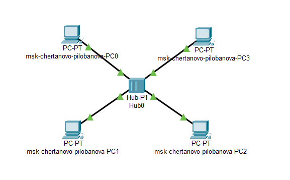

*Топология сети*

Перешла из режима реального времени (Realtime) в режим моделирования (Simulation). Выбрала на панели инструментов мышкой «Add Simple PDU (P)» и щёлкнула сначала на PC0, затем на PC2. Проследила за движением пакетов ARP и ICMP от устройства PC0 до устройства PC2 и обратно.

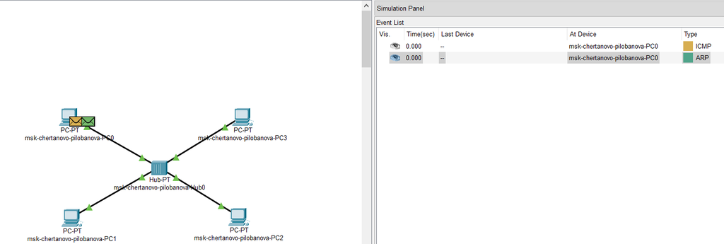

*Панель моделирования*

Открыла окно информации о PDU и изучила, что происходит на уровне модели OSI при перемещении пакета.

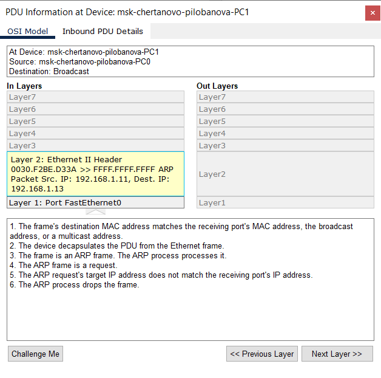

*Информация о PDU на уровне модели OSI*

Открыла вкладку с информацией о PDU. Исследовала структуру пакета ICMP.

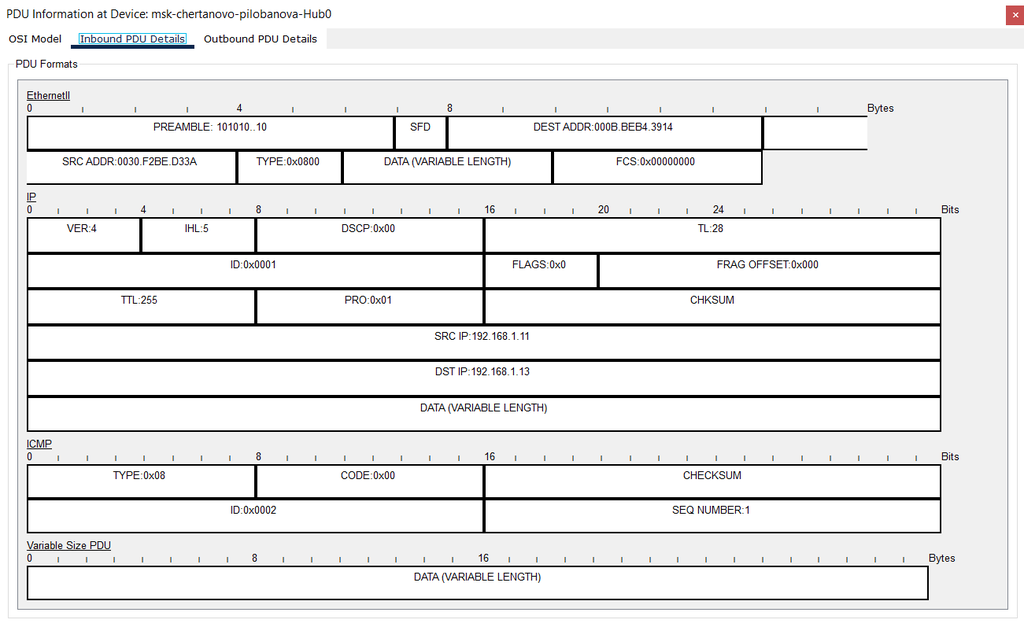

*Структура пакета ICMP*

Очистила список событий, удалив сценарий моделирования. Выбрала на панели инструментов мышкой «Add Simple PDU (P)» и щёлкнула сначала на PC0, затем на PC2. Снова щёлкнула сначала на PC2, затем на PC0. Проследила за возникновением коллизии. Коллизия возникает, когда оба пакета передаются на концентратор, поскольку он не может передавать несколько сообщений параллельно, далее один из пакетов пропадает, а другой передается дальше, но возникает ошибка.

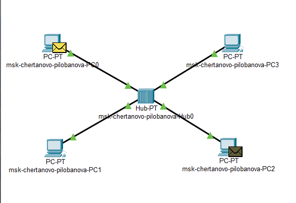

*Возникновение коллизии*

Перешла в режим реального времени (Realtime). В рабочем пространстве разместила коммутатор (Cisco 2950-24) и 4 оконечных устройства PC. Соединила оконечные устройства с коммутатором прямым кабелем. Щёлкнув последовательно на каждом оконечном устройстве, задала статические IP-адреса 192.168.1.21, 192.168.1.22, 192.168.1.23, 192.168.1.24 с маской подсети 255.255.255.0.

[figure not shown]

*Топология сети*

В основном окне проекта перешла из режима реального времени (Realtime) в режим моделирования (Simulation). Выбрала на панели инструментов мышкой «Add Simple PDU (P)» и щёлкнула сначала на PC4, затем на PC6. Проследила за движением пакетов ARP и ICMP от устройства PC4 до устройства PC6 и обратно.

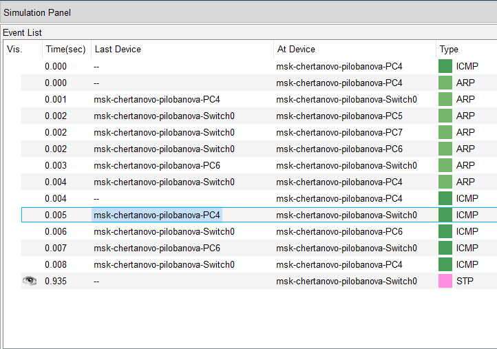

*Панель моделирования*

Выбрала на панели инструментов мышкой «Add Simple PDU (P)» и щёлкнула сначала на PC4, затем на PC6. Снова щёлкнула сначала на PC6, затем на PC4. Коллизия не возникает потому, что пакет не рассылается всем устройствам, а передается по нужным адресам коммутатором.

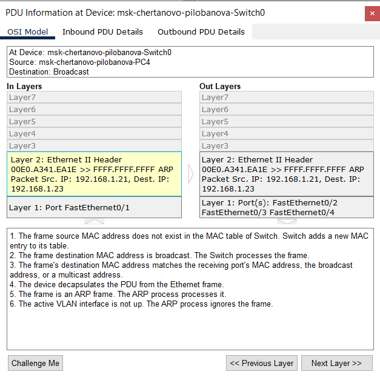

*Информация о PDU на уровне модели OSI*

Перешла в режим реального времени. В рабочем пространстве соединила кроссовым кабелем концентратор и коммутатор. Выбрала на панели инструментов мышкой «Add Simple PDU (P)» и щёлкнула сначала на PC0, затем на PC4. Снова щёлкнула сначала на PC4, затем на PC0.

[figure not shown]

*Информация о PDU на уровне модели OSI*

На панели моделирования нажала «Play» и в списке событий получила пакеты STP. Исследовала структуру STP. Пакет включает в себя идентификатор протокола, версию, тип, флаги, идентификатор корневого моста, расстояние до корневого моста, идентификатор моста, идентификатор порта, время жизни сообщения, максимальное время жизни сообщения, время приветствия и задержку смены состояния.

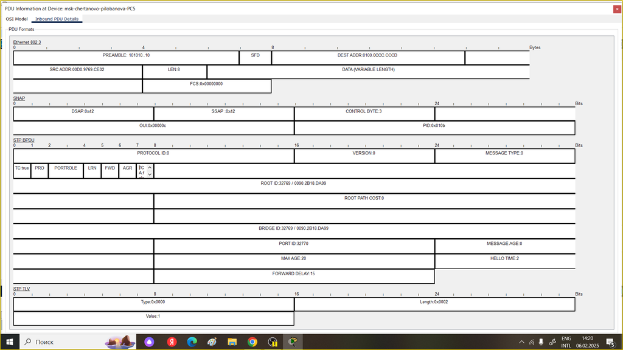

*Структура пакета STP*

Перешла в режим реального времени (Realtime). В рабочем пространстве добавила маршрутизатор (Cisco 2811). Соединила прямым кабелем коммутатор и маршрутизатор. Щёлкнула на маршрутизаторе и на вкладке его конфигурации прописала статический IP-адрес 192.168.1.254 с маской 255.255.255.0, активировала порт, поставив галочку «On» напротив «Port Status».

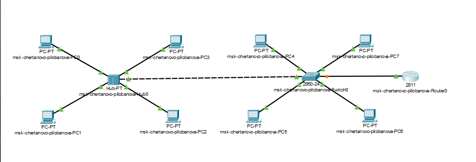

*Топология сети*

Перешла в режим моделирования (Simulation). Выбрала на панели инструментов мышкой «Add Simple PDU (P)» и щёлкнула сначала на PC3, затем на маршрутизаторе. Проследила за движением пакетов ARP, ICMP, STP и CDP. Исследовала структуру пакета CDP. Она включает в себя поле версии протокола, поле Time-to-Live (время жизни), контрольную сумму, тип, поле длины, поле значения, содержащее (в зависимости от параметра Type) тип протокола, длину поля протокола, длину прня адреса и адрес интерфейса.

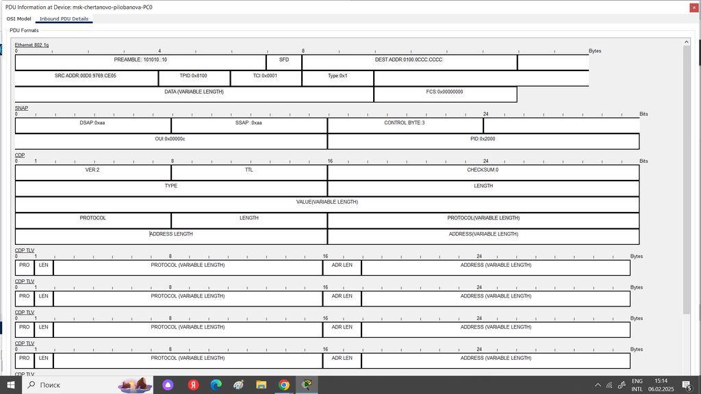

*Структура пакета CDP*

# Вывод

Я установила инструмент моделирования конфигурации сети Cisco Packet Tracer и познакомилась с его интерфейсом.